# Analysis Report(WeRateDogs Project)

## By Niharika Jain

### Date: 01/12/22

In this report, I am going to analyze some data gathered from WeRateDog's Twitter account with Visualization. I am answering the following questions:

## Analyze

> - Question 1. What is the most retweeted tweet?
> - Question 2. What is the most common rating?
> - Question 3. What are the most common breeds found by the neural network?
> - Question 4. What is the most Popular Twitter Source?
> - Question 5. Find out Top 5 Average Ratings, Favorite, Retweet Count By Dog Breed

## Visualization

> - Visualization 1: What is the average retweet count for each rating?
> - Visualization 2 - Top 10 Dog Breed
> - Visualization 3 - Which dog breed are most rated
> - Visualization 4 - The most favourite dog type?

## Question 1. What is the most retweeted tweet?

> Most Retweetd **Labrador Retriever** breed with **744234799360020481** tweet id has 71858 retweet count & 146597 favorite count.

```python
from IPython.display import Image
Image(filename='most_retweeted_twitter_handle.jpg', width=500)
```

[output not shown]

## Question 2. What is the most common rating?

> Most common rating is **12** which has given to **433** dogs.

## Question 3. What are the most common breeds found by the neural network?

> Most Common Breed is **Golden Retriever** with **128** count.  
> Top 5 common breeds are **'Golden Retriever', 'Pembroke', 'Labrador Retriever', 'Chihuahua', 'Pug'**.

## Question 4. What is the most Popular Twitter Source?

> Most Popular Twitter Souce is **Twitter for iPhone** with **1885** count.

## Question 5. Find out Top 5 Average Ratings, Favorite, Retweet Count By Dog Breed

> In Top 5 Average Favorite Count is **41788.0** for **Conch** breed.  
> Top 5 Average Favorite Dog Breeds by favorite count are **'Conch', 'Limousine', 'Angora', 'Fountain', 'Bubble'**.

## Visualize

For visualization, I used matplot lib libraries and save all charts in the local directory. I created 4 charts and each chart contains some common values so I created a function for common syntaxes.

```
def plotGrapgh(title,xlabel,ylabel,xrotation):
    plt.title(title,size=20)
    plt.xlabel(xlabel, fontsize=18)
    plt.ylabel(ylabel, fontsize=18)
    plt.xticks(rotation=xrotation, fontsize=16)
    plt.yticks(fontsize=16)
```

### Visualization 1: What is the average retweet count for each rating?

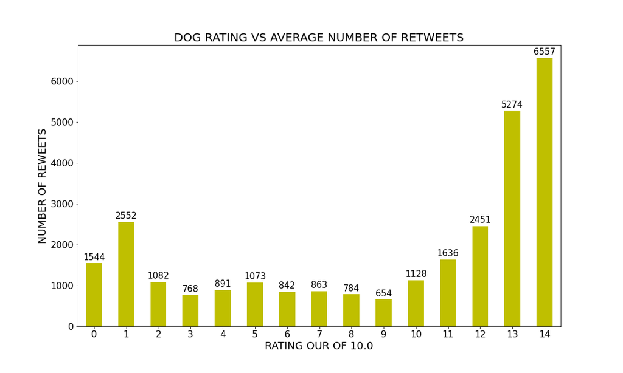

```python
Image(filename='Dog Rating vs Average Number of Retweets.png', width=700)
```

**As per the chart, dogs with a 14 rating have more retweets counts compared to a lower rating. For 14 rating dogs, no of Retweets are 6557 and for 13 rating value is 5274.**

### Visualization 2 - Top 10 Dog Breed

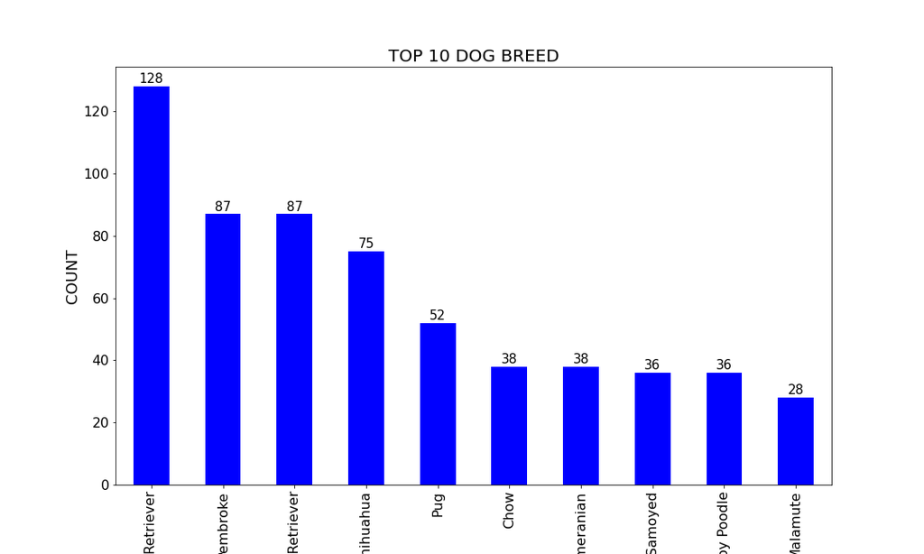

```python
Image(filename='Top 10 Dog Breed.png', width=700)
```

Most common dog breeds are **Golden Retriever, Pembroke, Labrador Retriever, Chihuahua** & **Pug**.

### Visualization 3 - Which dog breed are most rated

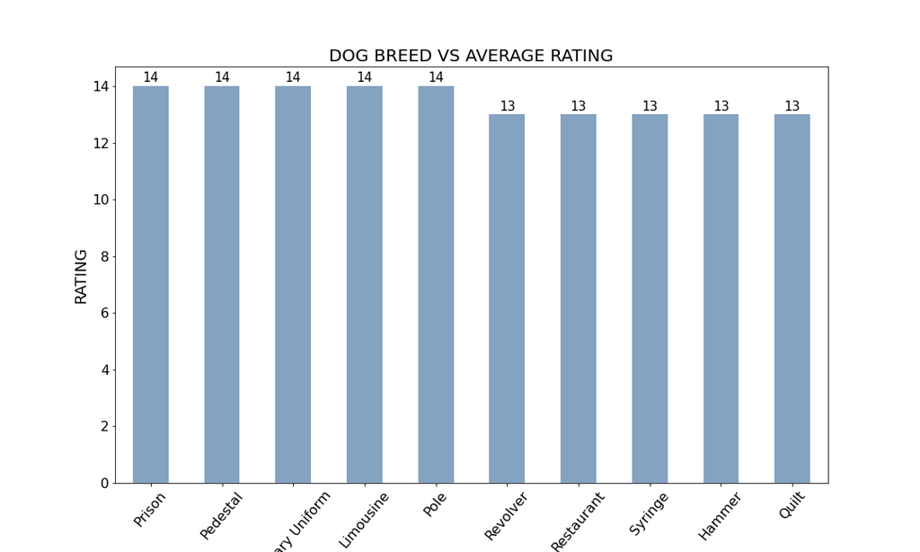

```python
Image(filename='Most rated Dog Breed.png', width=700)
```

Most common Dog Breeds as compared to Average Ratings are **Prison, Pedestal, Military Uniform, Limouine** & **Pole.**

### Visualization 4 - The most favourite dog type

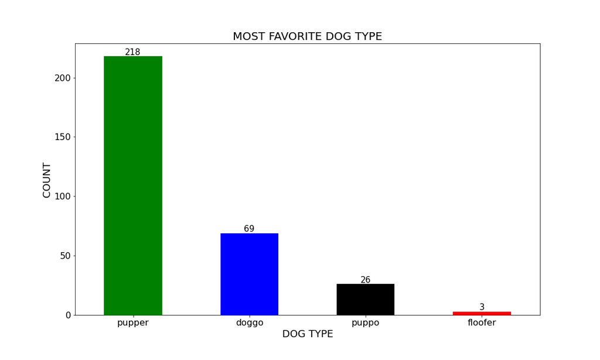

```python
Image(filename='Most Favorite Dog Type.png', width=700)
```

**Pupper** is the most favorite dog type with 218 count. **Floofer** is the least favorite one with 3 count only.